# ATPα Ancestral State Reconstruction and Sensitivity Analyses

ATPα Analysis Pipeline

2026-10-26

## Overview

This workflow reconstructs ancestral states of the ATPα (Na⁺/K⁺-ATPase α-subunit) functional motif across the Danaini phylogeny and tests how sensitive those reconstructions are. Each taxon’s functional state is the three-residue code at alignment positions **1 / 9 / 12** — VSH, VSN, LSN, QAN or LAN.

1. **ATPα ancestral state reconstruction (IQ-TREE)** — maximum-likelihood, empirical-Bayes (marginal) reconstruction under the LG amino-acid model on the Danaini tree, polarised with the outgroups *Heliconius erato* and *Mechanitis polymnia*.
2. **Robustness to phylogenetic uncertainty (bootstrap)** — the reconstruction repeated across the 1000 ultrafast-bootstrap trees of the Danaini backbone.
3. **Robustness to taxon sampling (jackknife)** — each sequenced taxon dropped in turn to see whether any single taxon drives an ancestral state.
4. **Robustness to incomplete taxon sampling (coverage)** — the reconstruction placed on the full Danaini tree, with unsampled taxa entered as missing data, to map where ancestral states are well supported versus interpolated across sampling gaps.
5. **Note on the AltAll test** — why the standard residue-level robustness check (Eick et al. 2017) is uninformative for this particular dataset.

Sections 2–4 use `phangorn` (same LG model) because they refit the model many times in-process; section 1 confirms `phangorn` and IQ-TREE give the same ancestral states on the reference tree, so the two are interchangeable here.

## Shared setup: configuration, data and tree

```r
positions <- c(1, 9, 12)                       # ATPα functional sites
AA <- c("A","R","N","D","C","Q","E","G","H","I",
        "L","K","M","F","P","S","T","W","Y","V")
pcol <- paste0("p_", AA)

# Outgroup priority for rooting (reversible model => marginal states are
# root-independent; rooting only fixes orientation and clade definitions).
outgroup_priority <- c("Heliconius_erato", "Mechanitis_polymnia")

state_cols <- c(VSH = "#c43240", VSN = "#f4a261", LSN = "#e9c46a",
                QAN = "#264653", LAN = "#287271")
code_color <- function(code) {
  out <- unname(state_cols[code]); out[is.na(out)] <- "lightgray"; out
}
```

The alignment already contains the four congener/subspecies-sourced tips (`Danaus_eresimus`, `Danaus_melanippus`, `Euploea_core`, `Heliconius_erato`) as records, so no in-script substitution is needed.

```r
sequences <- read.fasta("../input_data/alignment.fasta",
                        seqtype = "AA", as.string = TRUE)
seq_matrix <- matrix(nrow = length(sequences), ncol = nchar(sequences[[1]]))
for (i in seq_along(sequences)) {
  seq_matrix[i, ] <- strsplit(toupper(sequences[[i]]), "")[[1]]
}
rownames(seq_matrix) <- names(sequences)

tree0  <- read.tree("../input_data/Danaini_in_HOSTS.newick")
shared <- intersect(tree0$tip.label, rownames(seq_matrix))
cat("Alignment taxa:", nrow(seq_matrix), "| tree tips:", length(tree0$tip.label),
    "| taxa in both (analysed):", length(shared), "\n")
```

```
## Alignment taxa: 134 | tree tips: 56 | taxa in both (analysed): 19
```

```r
# Reconstruct ATPα focal states on a tree pruned to `taxa`. Returns the pruned,
# rooted tree and, per internal node, the 3-residue state code and its support
# (minimum of the max-posterior at the three focal positions).
recon <- function(src_tree, taxa) {
  tr <- keep.tip(src_tree, taxa)
  og <- outgroup_priority[outgroup_priority %in% taxa][1]
  if (!is.na(og)) tr <- root(tr, outgroup = og, resolve.root = TRUE)
  tr$node.label <- NULL
  tr <- makeNodeLabel(tr, method = "number", prefix = "N")

  fit <- pml(tr, phyDat(seq_matrix[taxa, , drop = FALSE], type = "AA"),
             model = "LG")
  fit <- optim.pml(fit, model = "LG", optGamma = FALSE, optEdge = TRUE,
                   control = pml.control(trace = 0))
  df <- as.data.frame(anc_pml(fit))
  n_tip <- length(tr$tip.label)

  code <- rep(NA_character_, tr$Nnode)
  supp <- rep(NA_real_, tr$Nnode)
  for (i in seq_len(tr$Nnode)) {
    sub <- df[df$Node == tr$node.label[i], ]
    if (nrow(sub) == 0) next   # phangorn unroots => root node has no state
    best <- vapply(positions, function(st) {
      p <- as.numeric(sub[sub$Site == st, pcol]); c(AA[which.max(p)], max(p))
    }, character(2))
    code[i] <- paste(best[1, ], collapse = "")
    supp[i] <- min(as.numeric(best[2, ]))
  }
  list(tree = tr, n_tip = n_tip, code = code, support = supp)
}

# Internal-node table keyed by descendant-taxon set (stable across prunings).
node_table <- function(rec) {
  map_dfr(seq_len(rec$tree$Nnode), function(i) {
    if (is.na(rec$code[i])) return(NULL)
    tips <- rec$tree$tip.label[Descendants(rec$tree, rec$n_tip + i,
                                           type = "tips")[[1]]]
    if (length(tips) < 2) return(NULL)
    tibble(node_id = rec$n_tip + i, key = paste(sort(tips), collapse = "|"),
           code = rec$code[i], support = rec$support[i])
  })
}
```

# 1. ATPα ancestral state reconstruction (IQ-TREE)

The primary reconstruction fixes the Danaini topology (`-te`), re-estimates branch lengths and model parameters on the ATPα alignment under LG+Γ, and reconstructs marginal ancestral states (`-asr`), rooted on the outgroups.

## Locate IQ-TREE

```r
iqtree_bin <- Sys.getenv(
  "IQTREE_BIN",
  unset = "/opt/anaconda3/envs/danaini-phylo/bin/iqtree")
if (!file.exists(iqtree_bin)) {
  found <- Sys.which(c("iqtree3", "iqtree2", "iqtree"))
  found <- found[found != ""]
  if (length(found) > 0) iqtree_bin <- unname(found[1]) else
    stop("IQ-TREE not found; set IQTREE_BIN to the binary in your conda env.")
}
cat("IQ-TREE:", iqtree_bin, "\n")
```

```
## IQ-TREE: /opt/anaconda3/envs/danaini-phylo/bin/iqtree
```

## Prune, root and write inputs

```r
ref_tree <- keep.tip(tree0, shared)
ref_tree <- root(ref_tree, outgroup = "Heliconius_erato", resolve.root = TRUE)

iqtree_dir <- "../output_data/iqtree_asr"
dir.create(iqtree_dir, showWarnings = FALSE, recursive = TRUE)
aln_path  <- file.path(iqtree_dir, "atpa_alignment.fasta")
tree_path <- file.path(iqtree_dir, "atpa_fixed_topology.treefile")
prefix    <- file.path(iqtree_dir, "atpa_asr")

seq_list <- lapply(shared, function(t) seq_matrix[t, ])
names(seq_list) <- shared
write.fasta(seq_list, names = shared, file.out = aln_path)
write.tree(ref_tree, file = tree_path)

cat("Analysed taxa:", length(shared), "| alignment sites:", ncol(seq_matrix), "\n")
```

```
## Analysed taxa: 19 | alignment sites: 12
```

## Run IQ-TREE

```r
outgroup_spec <- paste(intersect(outgroup_priority, shared), collapse = ",")
args <- c("-s", aln_path, "-te", tree_path, "-m", "LG+G", "-asr",
          "-o", outgroup_spec, "-pre", prefix, "-nt", "AUTO", "-redo")
log <- system2(iqtree_bin, args, stdout = TRUE, stderr = TRUE)

state_file <- paste0(prefix, ".state")
if (!file.exists(state_file)) { cat(paste(log, collapse = "\n")); stop("no .state") }
cat("IQ-TREE finished. Model/fit:\n")
```

```
## IQ-TREE finished. Model/fit:
```

```r
cat(paste(grep("Model of substitution|Log-likelihood of the tree",
               readLines(paste0(prefix, ".iqtree")), value = TRUE),
          collapse = "\n"), "\n")
```

```
## Model of substitution: LG+G4
## Log-likelihood of the tree: -56.3229 (s.e. 10.9910)
```

## Node posterior probabilities

```r
state_raw <- read.table(state_file, header = TRUE, sep = "\t",
                        comment.char = "#", check.names = FALSE)
p_cols <- grep("^p_", names(state_raw), value = TRUE)

posteriors_df <- state_raw %>%
  pivot_longer(all_of(p_cols), names_to = "state",
               names_prefix = "p_", values_to = "posterior") %>%
  transmute(site = Site, node_name = Node,
            node = as.integer(factor(Node, levels = unique(Node))),
            state, posterior) %>%
  arrange(site, node, state)

write.csv(posteriors_df, "../output_data/atpalpha_ASR_node_posteriors.csv",
          row.names = FALSE)
cat("Wrote ../output_data/atpalpha_ASR_node_posteriors.csv (",
    nrow(posteriors_df), "rows )\n")
```

```
## Wrote ../output_data/atpalpha_ASR_node_posteriors.csv ( 4080 rows )
```

## Reconstruction figure

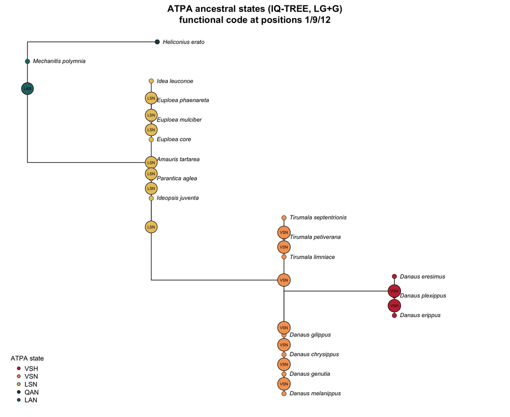

```r
iq_tree <- ladderize(read.tree(paste0(prefix, ".treefile")))
n_tip <- length(iq_tree$tip.label)

# Best (max-posterior) state per node/site
node_state <- state_raw %>% transmute(node_name = Node, site = Site, state = State)
anc_mat <- matrix("", nrow = length(unique(node_state$node_name)), ncol = ncol(seq_matrix),
                  dimnames = list(unique(node_state$node_name), NULL))
for (r in seq_len(nrow(node_state)))
  anc_mat[node_state$node_name[r], node_state$site[r]] <- node_state$state[r]

tip_code  <- apply(seq_matrix[iq_tree$tip.label, positions], 1, paste, collapse = "")
node_lab  <- iq_tree$node.label
node_code <- vapply(node_lab, function(nm)
  if (nm %in% rownames(anc_mat)) paste(anc_mat[nm, positions], collapse = "") else NA_character_,
  character(1))

draw_iq <- function() {
  par(mar = c(1, 1, 3, 1))
  plot(iq_tree, cex = 0.75, edge.width = 1.2, label.offset = 0.004,
       main = "ATPA ancestral states (IQ-TREE, LG+G)\nfunctional code at positions 1/9/12")
  tiplabels(pch = 21, bg = code_color(tip_code), col = "black", cex = 1.3, lwd = 0.6)
  for (i in seq_len(iq_tree$Nnode))
    nodelabels(node_code[i], node = n_tip + i, cex = 0.5, frame = "circle",
               bg = code_color(node_code[i]), col = "black")
  legend("bottomleft", bty = "n", title = "ATPA state",
         legend = names(state_cols), pt.bg = state_cols, pch = 21, cex = 0.85)
}
draw_iq()
```

```r
png("../visuals/atpalpha_ASR_tree.png", width = 1200, height = 1000, res = 120)
draw_iq(); dev.off()
```

```r
cat("Saved ../visuals/atpalpha_ASR_tree.png\n")
```

```
## Saved ../visuals/atpalpha_ASR_tree.png
```

## Cross-check: IQ-TREE vs phangorn

Confirms the `phangorn`-LG reconstruction used in the sensitivity sections reproduces the IQ-TREE states, so the two engines are interchangeable here.

```r
ph_ref <- node_table(recon(tree0, shared))
iq_code_by_clade <- function(tips) {
  nid <- getMRCA(iq_tree, tips); nm <- iq_tree$node.label[nid - n_tip]
  if (is.na(nm) || !(nm %in% rownames(anc_mat))) return(NA_character_)
  paste(anc_mat[nm, positions], collapse = "")
}
comp <- ph_ref %>%
  mutate(iqtree = map_chr(strsplit(key, "|", fixed = TRUE), iq_code_by_clade)) %>%
  filter(!is.na(iqtree)) %>%
  mutate(agree = iqtree == code)
cat(sprintf("Shared clades compared: %d | identical state code: %d (%.0f%%)\n",
            nrow(comp), sum(comp$agree), 100 * mean(comp$agree)))
```

```
## Shared clades compared: 17 | identical state code: 17 (100%)
```

# 2. Robustness to phylogenetic uncertainty (bootstrap)

Rather than trusting one tree, we repeat the reconstruction across the **1000 ultrafast-bootstrap trees** of the Danaini backbone (Hanson-Smith, Kolaczkowski & Thornton 2010). For each ancestral node (defined by its descendant taxa) we read the state at the **MRCA of those taxa** in every bootstrap tree, so a node can be judged even when the surrounding topology is reshuffled. We report how often the defining clade is monophyletic (topological support) and how often its ancestral state matches the reference (state robustness) — these can differ.

```r
boot_file <- paste0("../../Extended_Data_Figure1/output_data/danaini_tree/",
                    "supermatrix_ge1/supermatrix_ge1.ufboot")
stopifnot(file.exists(boot_file))

ref <- recon(tree0, shared)
ref_nodes <- node_table(ref) %>%
  mutate(tips = strsplit(key, "|", fixed = TRUE),
         n_taxa = lengths(tips))

boots <- read.tree(boot_file)
n_boot <- length(boots)

n_mono <- integer(nrow(ref_nodes)); n_same <- integer(nrow(ref_nodes))
alt <- vector("list", nrow(ref_nodes))
for (b in seq_len(n_boot)) {
  rb <- recon(boots[[b]], shared); tb <- rb$tree
  for (j in seq_len(nrow(ref_nodes))) {
    S <- ref_nodes$tips[[j]]
    mrca <- getMRCA(tb, S); code <- rb$code[mrca - rb$n_tip]
    if (isTRUE(is.monophyletic(tb, S))) n_mono[j] <- n_mono[j] + 1L
    if (!is.na(code) && code == ref_nodes$code[j]) n_same[j] <- n_same[j] + 1L
    alt[[j]] <- c(alt[[j]], code)
  }
}

boot_df <- ref_nodes %>%
  mutate(clade_freq = n_mono / n_boot,
         state_consistency = n_same / n_boot,
         alt_states = map2_chr(seq_along(alt), code, function(j, rc) {
           tb <- sort(table(alt[[j]]), decreasing = TRUE); tb <- tb[names(tb) != rc]
           if (length(tb) == 0) "" else
             paste(sprintf("%s:%.2f", names(tb), tb / n_boot), collapse = " ")
         })) %>%
  select(node_id, code, n_taxa, clade_freq, state_consistency, alt_states)

write.csv(boot_df, "../output_data/atpalpha_ASR_bootstrap_robustness.csv",
          row.names = FALSE)
cat(sprintf("Bootstrap trees: %d | nodes: %d\n", n_boot, nrow(boot_df)))
```

```
## Bootstrap trees: 1000 | nodes: 17
```

```r
cat(sprintf("State matches in >=95%% of trees: %d/%d | median consistency: %.3f\n",
            sum(boot_df$state_consistency >= 0.95), nrow(boot_df),
            median(boot_df$state_consistency)))
```

```
## State matches in >=95% of trees: 17/17 | median consistency: 1.000
```

```r
boot_df %>% arrange(state_consistency) %>%
  select(code, n_taxa, clade_freq, state_consistency, alt_states) %>%
  print(n = 50)
```

```
## # A tibble: 17 × 5
##    code  n_taxa clade_freq state_consistency alt_states
##    <chr>  <int>      <dbl>             <dbl> <chr>
##  1 VSH        3      0.984             0.99  "VSN:0.01"
##  2 VSN        7      1                 0.998 "VSH:0.00"
##  3 LAN       18      1                 1     ""
##  4 LSN       17      1                 1     ""
##  5 LSN       13      0.838             1     ""
##  6 LSN        3      1                 1     ""
##  7 LSN        2      1                 1     ""
##  8 VSN       10      1                 1     ""
##  9 VSN        4      0.815             1     ""
## 10 VSN        2      1                 1     ""
## 11 VSN        2      1                 1     ""
## 12 VSH        2      1                 1     ""
## 13 VSN        3      1                 1     ""
## 14 VSN        2      0.632             1     ""
## 15 LSN        4      1                 1     ""
## 16 LSN        3      1                 1     ""
## 17 LSN        2      0.8               1     ""
```

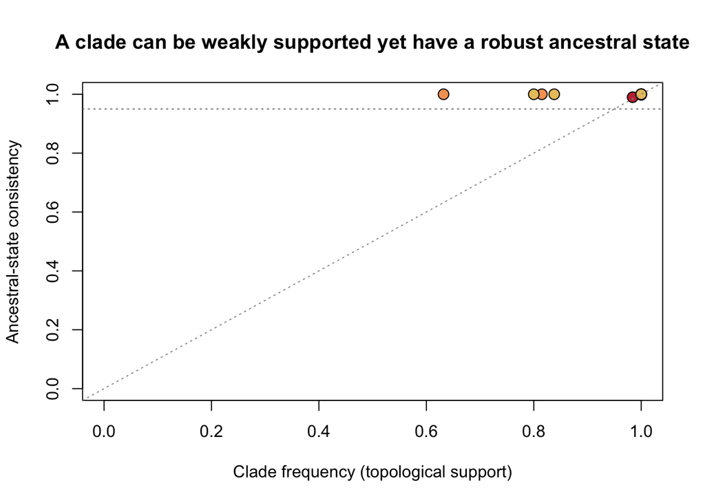

```r
plot(boot_df$clade_freq, boot_df$state_consistency, xlim = c(0, 1), ylim = c(0, 1),
     pch = 21, bg = code_color(boot_df$code), col = "black", cex = 1.4,
     xlab = "Clade frequency (topological support)",
     ylab = "Ancestral-state consistency",
     main = "A clade can be weakly supported yet have a robust ancestral state")
abline(0, 1, lty = 3, col = "grey60"); abline(h = 0.95, lty = 3, col = "grey50")
```

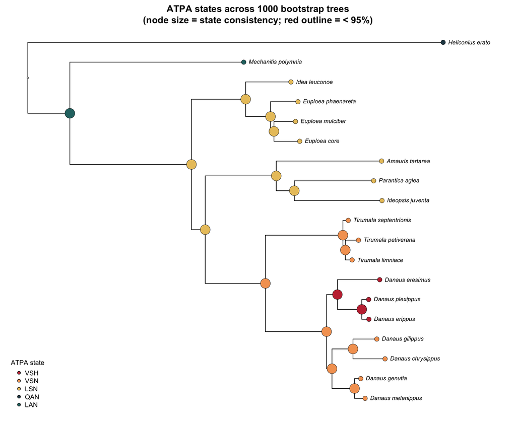

```r
tp <- ladderize(ref$tree); nt <- ref$n_tip
tip_code <- apply(seq_matrix[tp$tip.label, positions], 1, paste, collapse = "")
idx <- match((nt + 1):(nt + tp$Nnode), boot_df$node_id)
nd_fill <- code_color(boot_df$code[idx]); nd_fill[is.na(idx)] <- "grey85"
cons <- ifelse(is.na(idx), NA, boot_df$state_consistency[idx])
nd_out <- ifelse(!is.na(cons) & cons < 0.95, "red", "black")
nd_lwd <- ifelse(!is.na(cons) & cons < 0.95, 2.4, 0.6)
nd_cex <- 0.5 + 2.3 * ifelse(is.na(cons), 0, cons)

draw_boot <- function() {
  par(mar = c(1, 1, 3, 1))
  plot(tp, cex = 0.75, edge.width = 1.2, label.offset = 0.004,
       main = "ATPA states across 1000 bootstrap trees\n(node size = state consistency; red outline = < 95%)")
  tiplabels(pch = 21, bg = code_color(tip_code), col = "black", cex = 1.3, lwd = 0.6)
  nodelabels(pch = 21, bg = nd_fill, col = nd_out, cex = nd_cex, lwd = nd_lwd)
  legend("bottomleft", bty = "n", title = "ATPA state",
         legend = names(state_cols), pt.bg = state_cols, pch = 21, cex = 0.85)
}
draw_boot()
```

```r
png("../visuals/atpalpha_ASR_bootstrap.png", width = 1200, height = 1000, res = 120)
draw_boot(); dev.off()
```

```r
cat("Saved ../visuals/atpalpha_ASR_bootstrap.png\n")
```

```
## Saved ../visuals/atpalpha_ASR_bootstrap.png
```

# 3. Robustness to taxon sampling (jackknife)

Each of the 19 sequenced taxa is dropped in turn and the reconstruction repeated on the remaining taxa. For every reference node we record whether its state is unchanged; a flip names the taxon the state depended on.

```r
base_tbl <- node_table(recon(tree0, shared))

stab <- base_tbl %>%
  mutate(n_rep = 0L, n_stable = 0L, min_support_rep = support,
         alt_states = "", driver = NA_character_)

for (t in shared) {
  rep_tbl <- node_table(recon(tree0, setdiff(shared, t)))
  look <- setNames(seq_len(nrow(rep_tbl)), rep_tbl$key)
  for (j in seq_len(nrow(stab))) {
    k2 <- paste(setdiff(strsplit(stab$key[j], "|", fixed = TRUE)[[1]], t),
                collapse = "|")
    if (!is.na(look[k2])) {
      r <- rep_tbl[look[k2], ]
      stab$n_rep[j] <- stab$n_rep[j] + 1L
      stab$min_support_rep[j] <- min(stab$min_support_rep[j], r$support)
      if (r$code == stab$code[j]) stab$n_stable[j] <- stab$n_stable[j] + 1L
      else {
        stab$alt_states[j] <- paste(unique(c(
          if (nzchar(stab$alt_states[j])) stab$alt_states[j], r$code)), collapse = ",")
        stab$driver[j] <- paste(na.omit(unique(c(stab$driver[j], t))), collapse = ";")
      }
    }
  }
}
stab <- stab %>%
  mutate(stability = ifelse(n_rep > 0, n_stable / n_rep, NA_real_),
         n_taxa = lengths(strsplit(key, "|", fixed = TRUE))) %>%
  arrange(stability)

write.csv(stab %>% select(code, n_taxa, n_rep, n_stable, stability,
                          support, min_support_rep, alt_states, driver),
          "../output_data/atpalpha_ASR_jackknife_stability.csv", row.names = FALSE)

n_comp <- sum(stab$n_rep); n_flip <- sum(stab$n_rep - stab$n_stable)
cat(sprintf("Node x replicate comparisons: %d | state changes: %d (%.2f%%)\n",
            n_comp, n_flip, 100 * n_flip / n_comp))
```

```
## Node x replicate comparisons: 310 | state changes: 1 (0.32%)
```

```r
cat(sprintf("Nodes never flipped: %d of %d\n",
            sum(stab$stability == 1), nrow(stab)))
```

```
## Nodes never flipped: 16 of 17
```

```r
cat("\nNodes that ever change state when a taxon is dropped:\n")
```

```
##
## Nodes that ever change state when a taxon is dropped:
```

```r
stab %>% filter(stability < 1) %>%
  select(code, n_taxa, stability, alt_states, driver) %>% print(n = 50)
```

```
## # A tibble: 1 × 5
##   code  n_taxa stability alt_states driver
##   <chr>  <int>     <dbl> <chr>      <chr>
## 1 LAN       18     0.944 LSN        Mechanitis_polymnia
```

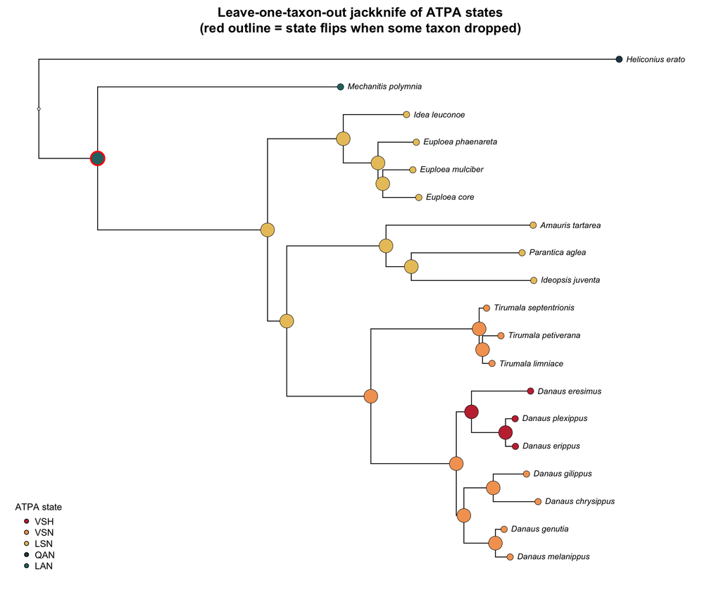

```r
tj <- ladderize(recon(tree0, shared)$tree); nt <- length(tj$tip.label)
tip_code <- apply(seq_matrix[tj$tip.label, positions], 1, paste, collapse = "")
idx <- match((nt + 1):(nt + tj$Nnode), stab$node_id)
nd_fill <- code_color(stab$code[idx]); nd_fill[is.na(idx)] <- "grey85"
nd_out  <- ifelse(!is.na(idx) & stab$stability[idx] < 1, "red", "black")
nd_lwd  <- ifelse(!is.na(idx) & stab$stability[idx] < 1, 2.4, 0.6)
nd_cex  <- 0.6 + 2.2 * ifelse(is.na(idx), 0, stab$min_support_rep[idx])

draw_jk <- function() {
  par(mar = c(1, 1, 3, 1))
  plot(tj, cex = 0.75, edge.width = 1.2, label.offset = 0.004,
       main = "Leave-one-taxon-out jackknife of ATPA states\n(red outline = state flips when some taxon dropped)")
  tiplabels(pch = 21, bg = code_color(tip_code), col = "black", cex = 1.3, lwd = 0.6)
  nodelabels(pch = 21, bg = nd_fill, col = nd_out, cex = nd_cex, lwd = nd_lwd)
  legend("bottomleft", bty = "n", title = "ATPA state",
         legend = names(state_cols), pt.bg = state_cols, pch = 21, cex = 0.85)
}
draw_jk()
```

```r
png("../visuals/atpalpha_ASR_jackknife.png", width = 1200, height = 1000, res = 120)
draw_jk(); dev.off()
```

```r
cat("Saved ../visuals/atpalpha_ASR_jackknife.png\n")
```

```
## Saved ../visuals/atpalpha_ASR_jackknife.png
```

# 4. Robustness to incomplete taxon sampling (coverage)

Only 19 of the Danaini tree’s tips carry ATPα data; the main reconstruction prunes the rest away. Here we instead place the reconstruction on the **full tree**, entering the unsampled taxa as missing data, to show where ancestral states are genuinely supported versus interpolated across sampling gaps. IQ-TREE rejects all-gap sequences, so this uses `phangorn` (LG), which tolerates them; we confirm it reproduces the Section 1 states where they overlap.

```r
ftree <- root(tree0, outgroup = "Heliconius_erato", resolve.root = TRUE)
ftree$node.label <- NULL
ftree <- ladderize(makeNodeLabel(ftree, method = "number", prefix = "Node"))
n_ftip <- length(ftree$tip.label)
n_site <- ncol(seq_matrix)

data_taxa    <- intersect(ftree$tip.label, rownames(seq_matrix))
missing_taxa <- setdiff(ftree$tip.label, rownames(seq_matrix))
cat(sprintf("Full tree: %d tips | with ATPA data: %d | missing (gaps): %d (%.0f%%)\n",
            n_ftip, length(data_taxa), length(missing_taxa),
            100 * length(missing_taxa) / n_ftip))
```

```
## Full tree: 56 tips | with ATPA data: 19 | missing (gaps): 37 (66%)
```

```r
full_rows <- lapply(ftree$tip.label, function(t)
  if (t %in% rownames(seq_matrix)) seq_matrix[t, ] else rep("-", n_site))
names(full_rows) <- ftree$tip.label
full_mat <- do.call(rbind, full_rows)
```

```r
cfit <- pml(ftree, phyDat(full_mat, type = "AA"), model = "LG")
cfit <- optim.pml(cfit, model = "LG", optGamma = FALSE, optEdge = TRUE,
                  control = pml.control(trace = 0))
anc_df <- as.data.frame(anc_pml(cfit))
fp_cols <- grep("^p_", names(anc_df), value = TRUE)

posteriors_full <- anc_df %>% filter(Node %in% ftree$node.label) %>%
  pivot_longer(all_of(fp_cols), names_to = "state",
               names_prefix = "p_", values_to = "posterior") %>%
  transmute(site = Site, node_name = Node, state, posterior) %>%
  arrange(site, node_name, state)
write.csv(posteriors_full,
          "../output_data/atpalpha_ASR_full_tree_posteriors.csv", row.names = FALSE)
cat("Wrote ../output_data/atpalpha_ASR_full_tree_posteriors.csv\n")
```

```
## Wrote ../output_data/atpalpha_ASR_full_tree_posteriors.csv
```

```r
best_at <- function(nl, site) {
  row <- anc_df[anc_df$Node == nl & anc_df$Site == site, fp_cols]
  j <- which.max(as.numeric(row))
  c(state = sub("^p_", "", fp_cols[j]), p = as.numeric(row)[j])
}
# phangorn unroots => the root node has no reconstruction; drive off present labels
rec_nodes <- intersect(ftree$node.label, unique(anc_df$Node))
coverage_df <- map_dfr(rec_nodes, function(lab) {
  nid  <- n_ftip + match(lab, ftree$node.label)
  tips <- ftree$tip.label[Descendants(ftree, nid, type = "tips")[[1]]]
  calls <- vapply(positions, function(s) best_at(lab, s), character(2))
  tibble(node = lab, n_descendants = length(tips),
         n_with_data = sum(tips %in% data_taxa),
         coverage = sum(tips %in% data_taxa) / length(tips),
         state_code = paste(calls["state", ], collapse = ""),
         support = min(as.numeric(calls["p", ]))) }) %>%
  arrange(desc(n_descendants))
write.csv(coverage_df, "../output_data/atpalpha_ASR_coverage.csv", row.names = FALSE)

cat(sprintf("Internal nodes: %d | zero-data (pure interpolation): %d | support >= 0.9: %d\n",
            nrow(coverage_df), sum(coverage_df$n_with_data == 0),
            sum(coverage_df$support >= 0.9)))
```

```
## Internal nodes: 54 | zero-data (pure interpolation): 13 | support >= 0.9: 47
```

```r
# Cross-check: full-tree states vs the Section 1 IQ-TREE states on shared clades
full_code <- function(tips) {
  nid <- getMRCA(ftree, tips)
  coverage_df$state_code[match(ftree$node.label[nid - n_ftip], coverage_df$node)]
}
iq_code3 <- function(nm) if (!is.na(nm) && nm %in% rownames(anc_mat))
  paste(anc_mat[nm, positions], collapse = "") else NA_character_
niq <- length(iq_tree$tip.label)
ccomp <- map_dfr(seq_len(iq_tree$Nnode), function(i) {
  tips <- iq_tree$tip.label[Descendants(iq_tree, niq + i, type = "tips")[[1]]]
  if (length(tips) < 2) return(NULL)
  tibble(iqtree = iq_code3(iq_tree$node.label[i]), full_tree = full_code(tips))
}) %>% filter(!is.na(iqtree) & !is.na(full_tree)) %>% mutate(agree = iqtree == full_tree)
cat(sprintf("Full-tree vs IQ-TREE on shared clades: %d/%d identical (%.0f%%)\n",
            sum(ccomp$agree), nrow(ccomp), 100 * mean(ccomp$agree)))
```

```
## Full-tree vs IQ-TREE on shared clades: 16/16 identical (100%)
```

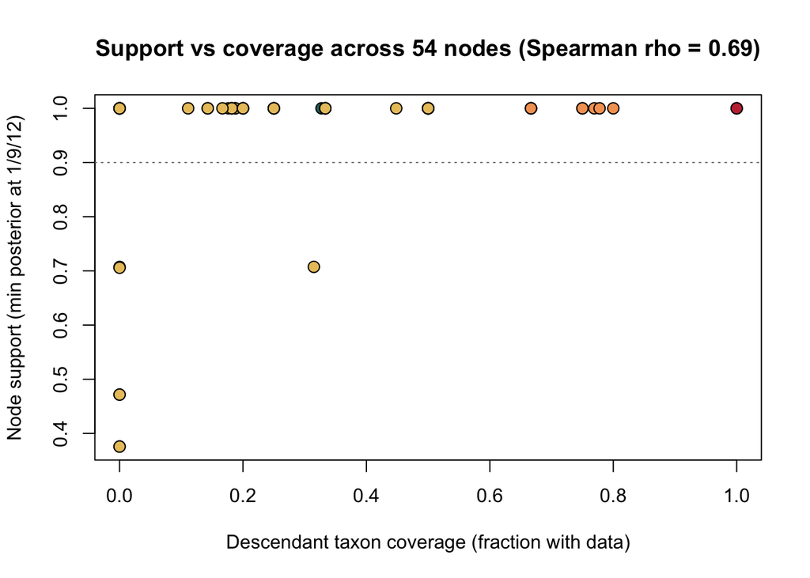

```r
rho <- cor(coverage_df$coverage, coverage_df$support, method = "spearman")
plot(coverage_df$coverage, coverage_df$support, pch = 21,
     bg = code_color(coverage_df$state_code), col = "black", cex = 1.3,
     xlab = "Descendant taxon coverage (fraction with data)",
     ylab = "Node support (min posterior at 1/9/12)",
     main = sprintf("Support vs coverage across %d nodes (Spearman rho = %.2f)",
                    nrow(coverage_df), rho))
abline(h = 0.9, lty = 3, col = "grey50")
```

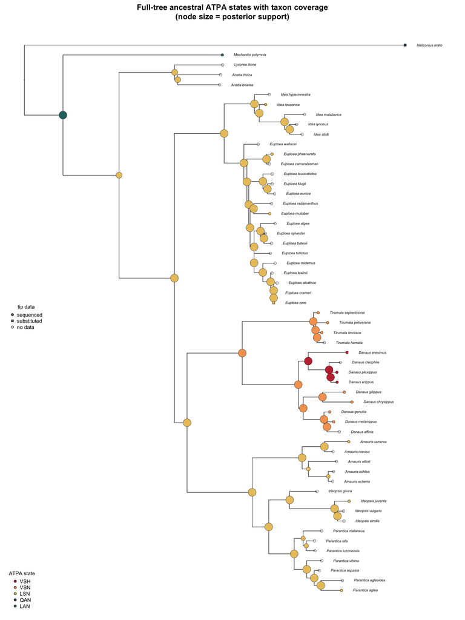

```r
substituted <- c("Danaus_eresimus", "Danaus_melanippus", "Euploea_core", "Heliconius_erato")
tip_code <- apply(full_mat[ftree$tip.label, positions], 1, paste, collapse = "")
tip_has  <- ftree$tip.label %in% data_taxa
tip_bg   <- ifelse(tip_has, code_color(tip_code), "white")
tip_pch  <- ifelse(!tip_has, 1, ifelse(ftree$tip.label %in% substituted, 22, 21))

ord <- match(ftree$node.label, coverage_df$node)
nd_col <- code_color(coverage_df$state_code[ord]); nd_col[is.na(ord)] <- "grey80"
nd_cex <- 0.5 + 2.2 * coverage_df$support[ord];    nd_cex[is.na(ord)] <- 0.3

draw_cov <- function() {
  par(mar = c(1, 1, 3, 1))
  plot(ftree, cex = 0.55, edge.width = 1, label.offset = 0.01,
       main = "Full-tree ancestral ATPA states with taxon coverage\n(node size = posterior support)")
  tiplabels(pch = tip_pch, bg = tip_bg, col = "black", cex = 0.9, lwd = 0.6)
  nodelabels(pch = 21, bg = nd_col, col = "black", cex = nd_cex, lwd = 0.5)
  legend("bottomleft", bty = "n", title = "ATPA state",
         legend = names(state_cols), pt.bg = state_cols, pch = 21, cex = 0.8)
  legend("left", bty = "n", title = "tip data",
         legend = c("sequenced", "substituted", "no data"),
         pch = c(21, 22, 1), pt.bg = c("grey40", "grey40", "white"), cex = 0.8)
}
draw_cov()
```

```r
png("../visuals/atpalpha_ASR_coverage.png", width = 1200, height = 1600, res = 120)
draw_cov(); dev.off()
```

```r
cat("Saved ../visuals/atpalpha_ASR_coverage.png\n")
```

```
## Saved ../visuals/atpalpha_ASR_coverage.png
```

# 5. Note: why the AltAll residue-level test is uninformative here

A third gold-standard ASR robustness check is **AltAll** (Eick, Bridgham, Anderson, Harms & Thornton 2017): build an alternative ancestor that substitutes the *second-most-probable* residue at every ambiguously reconstructed position, and confirm the conclusion holds for both the maximum-a-posteriori and the AltAll sequence. We ran it and it is **trivially satisfied here** — not because the analysis is weak, but because of the structure of this dataset. The evidence:

```r
# (a) Only the functional columns vary at all
var_cols <- which(apply(seq_matrix[shared, ], 2,
                        function(c) length(unique(c)) > 1))
cat("Variable alignment columns:", paste(var_cols, collapse = ", "),
    "(all other sites invariant)\n")
```

```
## Variable alignment columns: 1, 9, 12 (all other sites invariant)
```

```r
# (b) At the focal positions, the second-best residue is essentially zero
foc <- state_raw[state_raw$Site %in% positions, ]
p2 <- apply(foc[, p_cols], 1, function(p) sort(p, decreasing = TRUE)[2])
cat(sprintf("Max 2nd-best posterior at any focal node/position: %.4f\n", max(p2)))
```

```
## Max 2nd-best posterior at any focal node/position: 0.0000
```

```r
cat("AltAll cutoff is typically 0.20 -> no residue qualifies for swapping.\n")
```

```
## AltAll cutoff is typically 0.20 -> no residue qualifies for swapping.
```

**Interpretation.** The ATPα “alignment” used for the functional call is really the functional motif: the only variable columns are the three focal positions (the other nine are invariant), so the ancestral *sequence* reduces to the state code and AltAll over the sequence is AltAll over positions 1/9/12. At those positions every ancestral node is reconstructed essentially deterministically (second-best posterior ≈ 0, far below the 0.20 swap threshold), under both IQ-TREE and phangorn-LG. There is simply no plausible alternative residue to swap in, so MAP and AltAll are identical and the functional calls are robust to residue-level reconstruction uncertainty **by construction**.

This happens because (i) the functional states are distributed on the tree with very little homoplasy, and (ii) with only three variable sites, branch lengths optimised on this alignment are driven toward zero, which pins each internal node to its neighbours’ state. The result is real but weak as an independent stress test: with so few variable sites the reconstruction has little room to express residue-level uncertainty. For this dataset the uncertainty that matters is therefore **topological** (Section 2) and **taxon sampling** (Section 3), not residue-level ambiguity — which is why those are the informative tests here.

## Session Info

```r
cat("IQ-TREE binary:", iqtree_bin, "\n\n")
```

```
## IQ-TREE binary: /opt/anaconda3/envs/danaini-phylo/bin/iqtree
```